# **LINKED LIST**

Bahasa pemrograman python telah menyediakan type data yang dinamis, yaitu List. Ukuran dari variabel yang bertipe data list dapat diatur sesuai dengan keinginan programmer selama program dijalankan, tidak harus mempunyai ukuran tetap di awal. Tipe data ini juga menyediakan method menambah data pada saat diperlukan, sehingga tipe data ini bersifat dinamis. Akan tetapi tidak semua pemrograman menyediakan type data seperti ini, oleh karena itu terdapat suatu struktur data yang dapat dibuat oleh programmer yang bersifat dinamis, yaitu Linked List.

Lima hal utama yang terdapat pada struktur data linked list:

1. Node
2. Linked List
3. Penambahan Data pada Linked List
4. Traversal Linked List
5. Ordered List

## **Node**

Data di dalam memory berada di alamat yang berbeda-beda, jika dibutuhkan agar data-data tersebut dapat terhubung satu sama lain, maka informasi tambahan yang menunjukkan alamat data berikutnya sangatlah diperlukan, seperti yang terlihat pada Gambar 1 berikut.

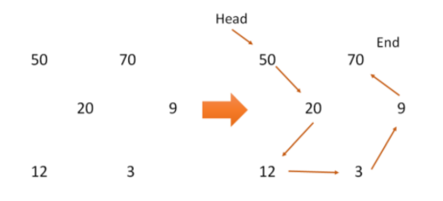

Oleh karena itu data berikutnya dapat diketahui dengan cari mengikuti informasi link yang terdapat

pada informasi tambahan tersebut. Lokasi data pertama dari linked list haruslah diketahui secara eksplisit, sehingga dari data pertama tersebut, data kedua data ditemukan, data ketiga, dan seterusnya. Informasi yang menunjuk pada lokasi data pertama atau head of the list tersebut disebut dengan external reference. Begitu juga dengan data terakhir, harus ada informasi yang menunjukkan bahwa data tersebut adalah data terakhir di dalam linked list, tidak ada lagi data berikutnya.

Untuk membuat struktur data linked list, terlebih dahulu dibuat node-node penyusun linked list tersebut. Node ini harus memiliki setidaknya dua informasi, yaitu informasi mengenai data atau nilai, dan informasi mengenai node berikutnya. Oleh karena itu node dibuat menjadi sebuah tipe data baru yang bertipe class, dengan dua informasi yaitu data dan next.

Terdapat beberapa method penting pada class node ini, antara lain:

- constructor, yang akan dijalankan setiap instansiasi class
- getData, untuk mengetahui informasi data yang terdapat pada node tersebut
- getNext, untuk mengetahui informasi node berikutnya, jika tidak ada node berikutnya maka nilai balik berupa None
- setData, untuk merubah informasi data yang terdapat pada node tersebut setNext, untuk menentukan node berikutnya yang ditunjukan oleh informasi next dari node tersebut

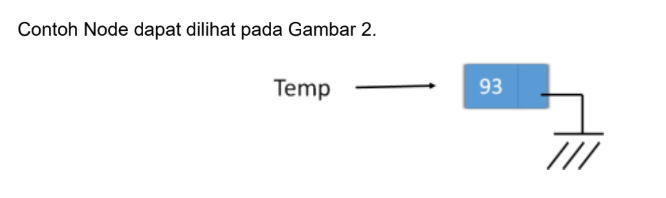

Gambar 2. Node dengan nilai '93'

Pada Gambar 2 tersebut, terdapat dua informasi yang terkandung di dalam node, yaitu data dari node adalah 93, dan node tersebut menunjuk ke Nil atau Ground atau tidak ada node yang ditunjuk.

## **Code**

Berikut adalah pembuatan class Node yang merupakan representasi dari sebuah node. Property atau state yang terdapat pada class Node ini :

1. data : berisi nilai dari node
2. next : berisi informasi berikutnya yang ditunjuk oleh node. Proses intansiasi, property next ini diset None yang merupakan representasi Nil atau Ground, berarti tidak ada node yang ditunjuk oleh node ini

```python
class Node:
    def __init__(self, init_data):
    self.data = init_data
    self.next = None
    def getData(self):
    return self.data
    def getNext(self):
    return self.next
    def setData(self, newdata):
    self.data = newdata
    def setNext(self, new_next):
    self.next = new_next
```

```python
a=Node(93)
b=Node(20)
print(a.getNext())
print(b.getNext())
a.setNext(b)
print(a.getNext())
```

Pada code diatas, terdapat obyek a dan obyek b yang memiliki tipe data class Node . Pada saat instansiasi, property data kedua obyek ini bernilai 93 dan 20 , serta property next bernilai **None.**

Pada baris kelima, terdapat perintah a.setNext(b) , yang berarti property next dari obyek a akan menunjuk ke obyek b . Sehingga ketika dilakukan perintah print(a.getNext()) akan menunjukkan ke suatu class Node.

### **Linked List Class**

Linked list merupakan kumpulan dari node-node yang terhubung satu sama lain. Untuk mengakses node-node yang terdapat pada linked list tersebut, haruslah diketahui terlebih dahulu lokasi node pertama dari suatu linked list, sehingga diperlukan pointer tambahan untuk menunjukkan keberadaan node pertama.

### **Code**

Berikut adalah class untuk linked list, dimana pada class tersebut terdapat pointer yang menunjukkan node pertama dari suatu linked list (head). Terdapat dua buah method utama pada class LinkedList ini, antara lain:

1. constructor, **init** , yang merupakan method yang dijalankan pada saat pembuatan obyek. Karena obyek baru pertama kali dibuat, maka linked list masih kosong, sehingga pointer head masih bernilai None.
2. Method isEmpty , untuk pengecekan apakah linked list memiliki node ataukah tidak. Jika pointer head masih menunjuk pada None, maka linked list masih tidak memiliki node, sehingga return value adalah True.

```python
class LinkedList:
def __init__(self):
self.head = None
def isEmpty(self):
return self.head==None
```

```python
mylist=LinkedList()
```

```python
print(mylist.head)
mylist.isEmpty()
```

```python
print(mylist.head)
```

```python
mylist.isEmpty()
```

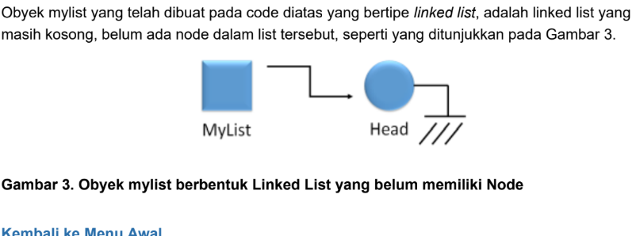

Penambahan Data pada Linked List

Secara default, penambahan data baru diletakkan pada awal linked list atau yang terdapat pada pointer head. Penambahan data baru ini, dilakukan dengan dua tahapan :

- Tautkan node baru ini ke node awal dari linked list
- modifikasi head dari linked list agar menunjuk pada node baru ini, seperti yang ditunjukkan pada Gambar 4 berikut :

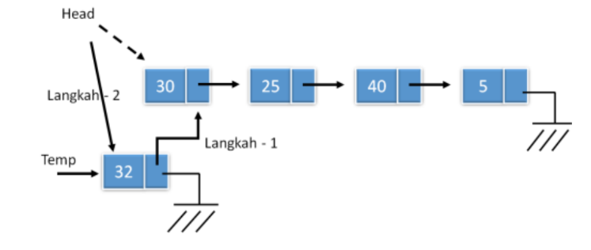

Gambar 4. Penambahan node baru secara benar pada linked list

Urutan tahapan ini tidak boleh dibalik, karena jika dibalik maka linked list yang awal tidak lagi dapat ditemukan seperti yang terdapat pada Gambar 5 berikut :

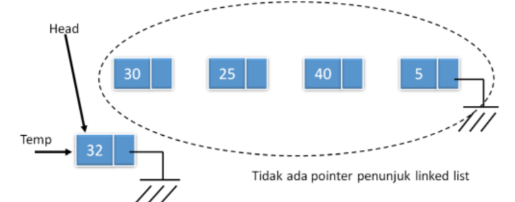

### **Code**

Berikut adalah penambahan method add() pada class LinkedList. Seperti yang dijelaskan sebelumnya, penambahan node baru harus dilakukan dengan urutan yang tepat, yaitu:

temp=Node(item) #temp adalah node baru yang akan ditambahkan temp.setNext(self.head) #pointer Next dari node temp menunjuk pada node yang ditunjuk oleh pointer head self.head=temp #pointer head menunjuk pada node temp yang sudah tersambu ng dengan linked list

```python
class LinkedList:
def __init__(self):
self.head = None
def isEmpty(self):
return self.head==None
def add(self, item):
temp = Node(item)
temp.setNext(self.head)
self.head = temp
```

```python
mylist=LinkedList()
```

```python
print(mylist.head)
mylist.isEmpty()
```

```python
mylist.add(34)
print(mylist.head)
```

```python
mylist.add(45)
print(mylist.head)
print(mylist.head.data)
```

```python
mylist.add(21)
```

Setelah penambahan node terakhir diatas, maka mylist akan berisi = [21, 45, 34]

## **Traversal Linked List**

Untuk mengetahui ukuran dari list, diperlukan tahapan traverse, yaitu menelusuri setiap node yang terdapat pada linked list, seperti pada Gambar 6 sebagai berikut :

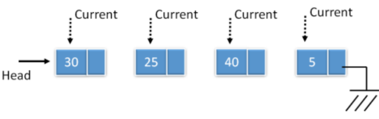

Gambar 6. Traversal Linked List Pada proses penelusuran atau traversal dibutuhkan pointer bantuan. Pointer bantuan yang ditunjukkan pada Gambar 6 tersebut, adalah pointer curent yang bergerak dari node awal sampai dengan node akhir.

Proses traversal ini dibutuhkan untuk beberapa hal, seperti untuk menghitung jumlah node yang terdapat pada Linked List, untuk mencari node pada linked list, untuk menampilkan seluruh node dari linked list, untuk menyisipkan node setelah atau sebelum node yang sudah terdapat pada linked list, dan untuk menghapus suatu node.

### **Code**

Implementasi pertama yang dibuat adalah pembuatan method size(), untuk menghitung jumlah node. Pada method size terdapat beberapa tahapan :

1. pointer bantuan curent berada pada node yang ditunjuk oleh head (yaitu node pertama)
2. pointer curent bergerak, dengan perintah curent=curent.getNext() , sekaligus dilakukan increment variabel count, yang merepresentasikan jumlah node
3. pergerakan atau traversal ini akan berakhir ketika pointer curent menunjuk pada None, yang merepresentasikan, tidak ada lagi node yang terdapat pada Linked list

```python
class LinkedList:
def __init__(self):
self.head = None
def isEmpty(self):
return self.head==None
def add(self, item):
temp = Node(item)
temp.setNext(self.head)
self.head = temp
def size(self):
curent = self.head
count = 0
while curent != None:
count = count + 1
curent = curent.getNext()
return count
```

Berikut contoh penggunaan method size() pada class LinkedList

```python
mylist=LinkedList()
mylist.add(45)
mylist.add(34)
mylist.add(70)
print(mylist.size())
```

Pencarian Node pada Linked List Untuk pencarian node di dalam linked list juga perlu dilakukan traverse linked list seperti sebelumnya, hanya saja setiap berada pada suatu node, maka dilakukan pencocokan apakah node tersebut adalah node yang dicari, seperti Gambar 7 berikut:

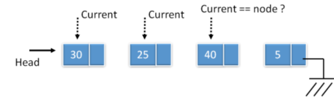

**Gambar 7. Pencarian Node pada Linked List**

Seperti halnya pada method sebelumnya, terdapat pointer curent yang bergerak dari awal sampai akhir, hanya saja diperlukan pencocokan antara data yang terdapat pada curent dengan data yang dicari. Implementasi pencarian dapat dilihat pada method berikut

### **Code**

Berikut penambahan method search() pada class LinkedList. Method search() ini hampir sama dengan method size , hanya saja jika ditambahkan apakah node yang ditunjukkan oleh pointer curent adalah node yang dicari, dengan perintah:

- if curent.getData() == item: #dimana item adalah node yang dicari

maka method ini akan menghasilkan nilai True.

```python
class LinkedList:
def __init__(self):
self.head = None
def isEmpty(self):
return self.head==None
def add(self, item):
temp = Node(item)
temp.setNext(self.head)
self.head = temp
def size(self):
curent = self.head
count = 0
while curent != None:
count = count + 1
curent = curent.getNext()
return count
def search(self,item):
curent = self.head
found = False
while curent != None and not found:
if curent.getData() == item:
found = True
else:
curent = curent.getNext()
return found
```

Berikut adalah contoh penggunaan method search()

```python
mylist=LinkedList()
mylist.add(45)
mylist.add(34)
mylist.add(70)
mylist.add(84)
mylist.size()
mylist.search(34)
```

**Menampilkan seluruh data pada Linked list**

Proses traversal juga dapat digunakan untuk menampilkan data pada seluruh node yang terdapat pada Linked List.

**Code**

Berikut method display() untuk menampilkan data dari seluruh node pada linked list

```python
class LinkedList:
def __init__(self):
self.head = None
def isEmpty(self):
return self.head==None
def add(self, item):
temp = Node(item)
temp.setNext(self.head)
self.head = temp
def size(self):
curent = self.head
count = 0
while curent != None:
count = count + 1
curent = curent.getNext()
return count
def search(self,item):
curent = self.head
found = False
while curent != None and not found:
if curent.getData() == item:
found = True
else:
curent = curent.getNext()
return found
def display(self):
curent = self.head
while curent != None:
print(curent.getData())
curent = curent.getNext()
```

Berikut adalah contoh penggunaan method display()

```python
mylist=LinkedList()
mylist.add(45)
mylist.add(34)
mylist.add(70)
mylist.add(84)
```

```python
mylist.display()
```

**Penghapusan Node pada Linked List**

Penghapusan data (remove data) dilakukan dengan dua tahapan yaitu

- traverse linked list, untuk mencari node mana yang akan dihapus
- remove data, menghapus node dari linked list

Untuk traverse linked list sama hal nya dengan method sebelumnya, yaitu terdapat pointer curent yang menelusuri node awal sampai dengan node akhir untuk mencari node yang akan dihapus. Ketika node sudah ditemukan, penghapusan tidak dapat dilakukan langsung begitu saja, karena di dalam node terdapat informasi lain, yaitu next yang menunjukkan lokasi node berikutnya. Sebelum dilakukan penghapusan perlu dilakukan terlebih dahulu pentautan antara node sebelum node yang dicari dengan node sesudah node yang dicari, sehingga node yang dicari dapat dihapus. Oleh karena itu diperlukan pointer tambahan selain curent, yaitu pointer previous. Pointer ini bergerak satu langkah sebelum pointer curent, sehingga ketika pointer curent sudah menemukan data yang dicari, maka pointer previous ini dapat ditautkan dengan node sesudah curent. Ilustrasi ketika data yang akan dihapus berada di tengah linked list ditunjukkan pada Gambar 8.

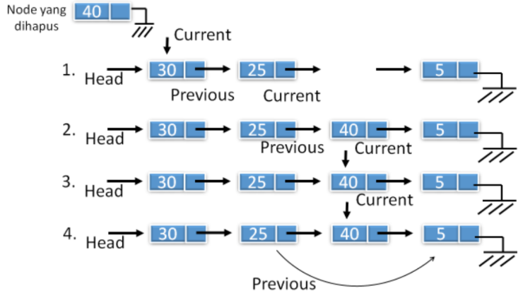

**Gambar 8. Penghapusan Node pada Linked List**

Jika data yang dihapus berada di node awal dari linked list (yang ditunjukkan dengan nilai previous masih None, maka yang dilakukan pointer head langsung menunjuk pada node setelah node yang akan dihapus tersebut, seperti Gambar 9 berikut:

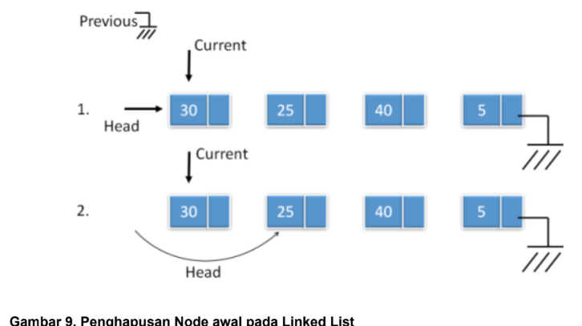

**Code**

Berikut adalah penambahan method remove() untuk menghapus node yang diinginkan pada linked list

```python
class LinkedList:
def __init__(self):
self.head = None
def isEmpty(self):
return self.head==None
def add(self, item):
temp = Node(item)
temp.setNext(self.head)
self.head = temp
def size(self):
curent = self.head
count = 0
while curent != None:
count = count + 1
curent = curent.getNext()
return count
def search(self,item):
curent = self.head
found = False
while curent != None and not found:
if curent.getData() == item:
found = True
else:
curent = curent.getNext()
return found
def display(self):
curent = self.head
while curent != None:
print(curent.getData())
curent = curent.getNext()
def remove(self, item):
curent = self.head
previous = None
found = False
while not found:
if curent.getData() == item:
found = True
else:
previous = curent
curent = curent.getNext()
if previous == None:
self.head = curent.getNext()
else:
previous.setNext(curent.getNext())
```

Berikut adalah contoh penggunaan method remove()

```python
mylist=LinkedList()
mylist.add(45)
mylist.add(34)
mylist.add(70)
mylist.add(84)
mylist.add(97)
mylist.display()
```

```python
mylist.remove(34)
```

```python
mylist.display()
```

## **Ordered List**

Proses pencarian pada linked list sebelumnya dilakukan dengan cara mencari node satu persatu sampai node terakhir. Proses pencarian ini akan menjadi lebih cepat jika data sudah dalam keadaan terurut, sehingga pencarian dapat dihentikan ketika ditemukan node dengan data lebih rendah atau lebih tinggi. Class Ordered List akan memudahkan pencarian suatu node, karena data yang terdapat pada class ini sudah dalam keadaan terurut.

Method yang terdapat pada ordered list, sama halnya dengan class linkedlist, hanya saja terdapat perbedaan pada method untuk add data (karena node yang terbentuk harus dalam keadaan terurut), dan method search data.

**Code**

Berikut method untuk class ordered list

```python
class OrderedLinkedList:
def __init__(self):
self.head = None
def isEmpty(self):
return self.head==None
def size(self):
curent = self.head
count = 0
while curent != None:
count = count + 1
curent = curent.getNext()
return count
def display(self):
curent = self.head
while curent != None:
print(curent.getData())
curent = curent.getNext()
def remove(self, item):
curent = self.head
previous = None
found = False
while not found:
if curent.getData() == item:
found = True
else:
previous = curent
curent = curent.getNext()
if previous == None:
self.head = curent.getNext()
else:
previous.setNext(curent.getNext())
def search(self,item):
curent = self.head
found = False
stop=False
while curent != None and not found and not stop:
if curent.getData() == item:
found = True
else:
if curent.getData() > item:
stop = True
else:
curent = curent.getNext()
return found
def add(self, item):
curent=self.head
previous = None
stop = False
while curent != None and not stop:
if curent.getData() > item:
stop = True
else:
previous = curent
curent = curent.getNext()
temp = Node(item)
if previous == None:
temp.setNext(self.head)
self.head = temp
else: # ditautkan antara previous dengan curent
temp.setNext(curent)
previous.setNext(temp)
```

Berikut adalah contoh penggunaan class ordered Linked List

```python
myList=OrderedLinkedList()
```

```python
myList.add(9)
```

```python
myList.add(14)
```

```python
myList.display()
```

```python
myList.display()
```

## **Daftar Bertautan**

Sebuah linked list terdiri dari node yang berisi data tertentu, dan sebuah pointer, atau link, ke node berikutnya.

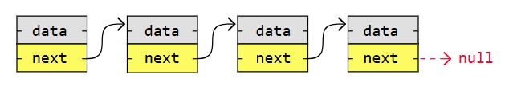

## Linked List vs Array

Cara termudah untuk memahami linked list mungkin dengan membandingkan linked list dengan array.

Linked list terdiri dari node, dan merupakan struktur data linier yang kita buat sendiri, tidak seperti array yang merupakan struktur data yang sudah ada dalam bahasa pemrograman yang dapat kita gunakan.

Node dalam linked list menyimpan tautan ke node lain, tetapi elemen array tidak perlu menyimpan tautan ke elemen lain.

**Catatan:** Cara penyimpanan linked list dan array di memori dijelaskan secara detail di halaman Linked Lists in Memory .

Berikut beberapa properti utama linked list, dibandingkan dengan array:

- Linked list tidak dialokasikan ke ukuran tetap dalam memori seperti halnya array, sehingga linked list tidak perlu memindahkan seluruh list ke ruang memori yang lebih besar ketika ruang memori tetap penuh, tidak seperti yang harus dilakukan oleh array.
- Node dalam linked list tidak disusun satu per satu secara berurutan di memori (berurutan), sehingga node dalam linked list tidak perlu digeser ke atas atau ke bawah di memori ketika node disisipkan atau dihapus.
- Node pada linked list membutuhkan lebih banyak memori untuk menyimpan satu atau lebih tautan ke node lain. Elemen array tidak membutuhkan memori sebanyak itu, karena elemen array tidak berisi tautan ke elemen lain.
- Operasi pada linked list biasanya lebih sulit diprogram dan membutuhkan lebih banyak baris kode daripada operasi array yang serupa, karena bahasa pemrograman memiliki dukungan bawaan yang lebih baik untuk array.
- Kita harus menelusuri linked list untuk menemukan node pada posisi tertentu, tetapi dengan array kita dapat mengakses elemen secara langsung dengan menulis myArray[5] .

## **Jenis-jenis Linked List**

Ada tiga bentuk dasar linked list:

1. Daftar berantai tunggal
2. Daftar berantai ganda
3. Daftar berantai melingkar

**Linked list tunggal**

adalah jenis linked list yang paling sederhana. Ia membutuhkan lebih sedikit ruang memori karena setiap node hanya memiliki satu alamat ke node berikutnya, seperti pada gambar di bawah ini.

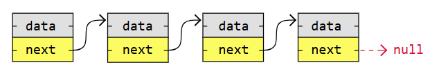

**Sebuah linked list ganda**

memiliki node dengan alamat ke node sebelumnya dan node berikutnya, seperti pada gambar di bawah, dan oleh karena itu membutuhkan lebih banyak memori. Namun, linked list ganda bagus jika Anda ingin dapat bergerak ke atas dan ke bawah dalam list.

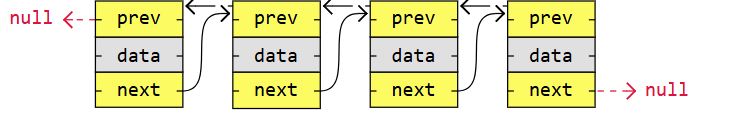

Linked list melingkar mirip dengan linked list tunggal atau ganda yang simpul pertama, "kepala", dan simpul terakhir, "ekor", terhubung.

Pada linked list tunggal atau ganda, kita dapat menemukan awal dan akhir suatu list hanya dengan memeriksa apakah link-nya null . Namun untuk linked list melingkar, diperlukan kode yang lebih kompleks untuk secara eksplisit memeriksa node awal dan akhir dalam aplikasi tertentu.

Linked list melingkar cocok untuk daftar yang perlu Anda telusuri secara terus-menerus.

Gambar di bawah ini adalah contoh dari linked list melingkar tunggal:

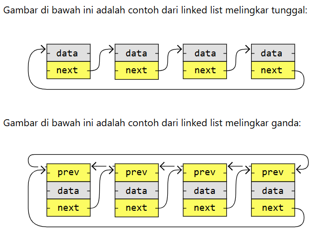

**Catatan:** Jenis linked list yang Anda butuhkan bergantung pada masalah yang ingin Anda selesaikan.

## **Operasi Daftar Tertaut**

Hal-hal mendasar yang dapat kita lakukan dengan linked list adalah:

1. Lintasan
2. Menghapus sebuah node
3. Sisipkan sebuah node
4. Menyortir

Untuk mempermudah, linked list tunggal akan digunakan untuk menjelaskan operasi-operasi di bawah ini

### **Penelusuran Daftar Tertaut**

Melakukan traversing pada linked list berarti menelusuri linked list dengan mengikuti tautan dari satu node ke node berikutnya.

Penelusuran pada linked list biasanya dilakukan untuk mencari node tertentu, dan membaca atau memodifikasi konten node tersebut, menghapus node, atau menyisipkan node tepat sebelum atau sesudah node tersebut.

Untuk menelusuri daftar berantai tunggal, kita mulai dari simpul pertama dalam daftar, yaitu simpul kepala, dan mengikuti tautan berikutnya dari simpul tersebut, dan tautan berikutnya dari simpul berikutnya, dan seterusnya, hingga alamat berikutnya adalah null.

```python
class Node:
  def __init__(self, data):
    self.data = data
    self.next = None

def traverseAndPrint(head):
  currentNode = head
  while currentNode:
    print(currentNode.data, end=" -> ")
    currentNode = currentNode.next
  print("null")

node1 = Node(7)
node2 = Node(11)
node3 = Node(3)
node4 = Node(2)
node5 = Node(9)

node1.next = node2
node2.next = node3
node3.next = node4
node4.next = node5

traverseAndPrint(node1)
```

### **Mencari Nilai Terendah dalam Daftar Tertaut**

Mari kita cari nilai terendah dalam linked list tunggal dengan menelusurinya dan memeriksa setiap nilainya.

Mencari nilai terendah dalam linked list sangat mirip dengan cara kita mencari nilai terendah dalam array , kecuali bahwa kita perlu mengikuti tautan berikutnya untuk sampai ke node berikutnya.

Untuk menemukan nilai terendah, kita perlu menelusuri daftar seperti pada kode sebelumnya. Namun, selain menelusuri daftar, kita juga harus memperbarui nilai terendah saat ini ketika kita menemukan node dengan nilai yang lebih rendah.

Dalam kode di bawah ini, algoritma untuk menemukan nilai terendah dipindahkan ke dalam sebuah fungsi bernama findLowestValue .

```python
class Node:
  def __init__(self, data):
    self.data = data
    self.next = None

def findLowestValue(head):
  minValue = head.data
  currentNode = head.next
  while currentNode:
    if currentNode.data < minValue:
      minValue = currentNode.data
    currentNode = currentNode.next
  return minValue

node1 = Node(7)
node2 = Node(11)
node3 = Node(3)
node4 = Node(2)
node5 = Node(9)

node1.next = node2
node2.next = node3
node3.next = node4
node4.next = node5

print("The lowest value in the linked list is:", findLowestValue(node1))
```

### **Menghapus Node dalam Linked List**

Jika Anda ingin menghapus sebuah node dalam linked list, penting untuk menghubungkan node di setiap sisi node tersebut sebelum menghapusnya, agar linked list tidak rusak.

Jadi, sebelum menghapus node, kita perlu mendapatkan pointer berikutnya dari node sebelumnya, dan menghubungkan node sebelumnya ke node berikutnya yang baru sebelum menghapus node di antaranya.

Selain itu, ada baiknya untuk terlebih dahulu menghubungkan pointer berikutnya ke node setelah node yang ingin kita hapus, sebelum kita menghapusnya. Hal ini untuk menghindari pointer yang 'menggantung', yaitu pointer yang menunjuk ke sesuatu yang tidak ada, meskipun hanya untuk sesaat.

Simulasi di bawah ini menunjukkan node yang ingin kita hapus, dan bagaimana daftar harus dilalui terlebih dahulu untuk menghubungkan daftar dengan benar sebelum menghapus node tanpa merusak linked list.

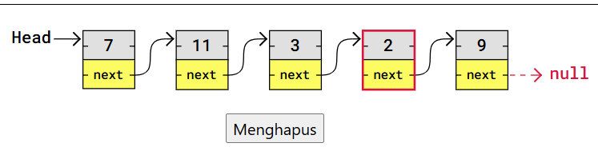

Dalam kode di bawah ini, algoritma untuk menghapus sebuah node dipindahkan ke dalam sebuah fungsi bernama deleteSpecificNode .

```python
class Node:
  def __init__(self, data):
    self.data = data
    self.next = None

def traverseAndPrint(head):
  currentNode = head
  while currentNode:
    print(currentNode.data, end=" -> ")
    currentNode = currentNode.next
  print("null")

def deleteSpecificNode(head, nodeToDelete):
  if head == nodeToDelete:
    return head.next

  currentNode = head
  while currentNode.next and currentNode.next != nodeToDelete:
    currentNode = currentNode.next

  if currentNode.next is None:
    return head

  currentNode.next = currentNode.next.next

  return head

node1 = Node(7)
node2 = Node(11)
node3 = Node(3)
node4 = Node(2)
node5 = Node(9)

node1.next = node2
node2.next = node3
node3.next = node4
node4.next = node5

print("Before deletion:")
traverseAndPrint(node1)

# Delete node4
node1 = deleteSpecificNode(node1, node4)

print("\nAfter deletion:")
traverseAndPrint(node1)
```

Pada fungsi deleteSpecificNode di atas, nilai kembaliannya adalah head baru dari linked list. Jadi, misalnya, jika node yang akan dihapus adalah node pertama, head baru yang dikembalikan akan menjadi node berikutnya.

### **Sisipkan Node ke dalam Linked List**

Menyisipkan sebuah node ke dalam linked list sangat mirip dengan menghapus sebuah node, karena dalam kedua kasus tersebut kita perlu memperhatikan pointer next untuk memastikan kita tidak merusak linked list.

Untuk menyisipkan sebuah node ke dalam linked list, pertama-tama kita perlu membuat node tersebut, dan kemudian pada posisi di mana kita menyisipkannya, kita perlu menyesuaikan pointer sehingga node sebelumnya menunjuk ke node baru, dan node baru menunjuk ke node berikutnya yang benar.

Simulasi di bawah ini menunjukkan bagaimana tautan disesuaikan saat memasukkan node baru.

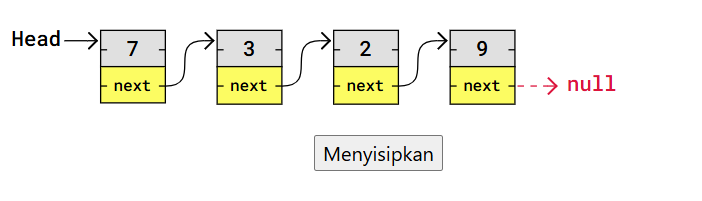

1. Node baru telah dibuat.
2. Node 1 terhubung ke node baru
3. Node baru terhubung ke node berikutnya.

```python
class Node:
  def __init__(self, data):
    self.data = data
    self.next = None

def traverseAndPrint(head):
  currentNode = head
  while currentNode:
    print(currentNode.data, end=" -> ")
    currentNode = currentNode.next
  print("null")

def insertNodeAtPosition(head, newNode, position):
  if position == 1:
    newNode.next = head
    return newNode

  currentNode = head
  for _ in range(position - 2):
    if currentNode.next is None:
      break
    currentNode = currentNode.next

  newNode.next = currentNode.next
  currentNode.next = newNode
  return head

node1 = Node(7)
node2 = Node(3)
node3 = Node(2)
node4 = Node(9)

node1.next = node2
node2.next = node3
node3.next = node4

print("Original list:")
traverseAndPrint(node1)

# Insert a new node with value 97 at position 2
newNode = Node(97)
node1 = insertNodeAtPosition(node1, newNode, 2)

print("\nAfter insertion:")
traverseAndPrint(node1)
```

Pada fungsi insertNodeAtPosition di atas, nilai kembaliannya adalah head baru dari linked list. Jadi, misalnya, jika node disisipkan di awal linked list, head baru yang dikembalikan akan menjadi node baru tersebut.

## **Kompleksitas Waktu Operasi Daftar Tertaut**

Ingatlah bahwa kompleksitas waktu hanya menyatakan perkiraan jumlah operasi yang dibutuhkan oleh algoritma berdasarkan kumpulan data yang besar (n), dan tidak memberi tahu kita waktu pasti yang dibutuhkan oleh implementasi spesifik dari suatu algoritma.

Ini berarti bahwa meskipun pencarian linear dikatakan memiliki kompleksitas waktu yang sama untuk array seperti untuk linked list: O(n), bukan berarti keduanya membutuhkan waktu yang sama. Waktu pasti yang dibutuhkan algoritma untuk berjalan bergantung pada bahasa pemrograman, perangkat keras komputer, perbedaan waktu yang dibutuhkan untuk operasi pada array vs linked list, dan banyak hal lainnya.

Pencarian linear untuk linked list bekerja sama seperti untuk array. Sebuah daftar nilai yang tidak terurut ditelusuri dari node kepala hingga node dengan nilai tertentu ditemukan. Kompleksitas waktunya adalah O(n).

Pencarian biner tidak mungkin dilakukan pada linked list karena algoritma tersebut didasarkan pada lompatan langsung ke elemen array yang berbeda, dan hal itu tidak mungkin dilakukan pada linked list.

# **LATIHAN PILGAN**

**1. Apa perbedaan utama antara Array dan Linked List?**

A. Array lebih fleksibel dalam ukuran, Linked List tidak

B. Array menggunakan memori yang berdekatan (contiguous), Linked List menggunakan memori yang tersebar

C. Linked List lebih lambat dalam akses data secara acak

D. Jawaban B dan C benar

**Jawaban: D (Jawaban B dan C benar)**

**2. Dalam Singly Linked List, setiap node terdiri dari...**

A. Data saja

B. Data dan pointer ke node sebelumnya

C. Data dan pointer ke node berikutnya

D. Data dan pointer ke node pertama

**Jawaban: C (Data dan pointer ke node berikutnya)**

**3. Berapakah kompleksitas waktu untuk menyisipkan node di awal (head) pada Singly Linked List?**

A. $O(1)$

B. $O(n)$

C. $O(\log n)$

D. $O(n^2)$

**Jawaban: A ($O(1)$)**

**4. Jika kita ingin menghapus node terakhir pada Singly Linked List, kita harus...**

A. Langsung menghapus head

B. Melakukan iterasi sampai ke node kedua terakhir, lalu mengubah pointer-nya menjadi None

C. Cukup memanggil fungsi pop()

D. Tidak bisa dilakukan

**Jawaban: B (Melakukan iterasi sampai ke node kedua terakhir, lalu mengubah pointer-nya menjadi None**

**5. Apa keuntungan utama dari Doubly Linked List dibandingkan Singly Linked List?** A. Membutuhkan memori yang lebih sedikit

B. Memungkinkan penelusuran data baik ke depan maupun ke belakang

C. Lebih cepat untuk semua operasi

D. Tidak memiliki pointer None

**Jawaban: B (Memungkinkan penelusuran data baik ke depan maupun ke belakang)**

# **LATIHAN CODE**

**Soal 1: Implementasi Dasar Node & Singly Linked List**

```python
class Node:
    def __init__(self, data):
        self.data = data
        self.next = None

class SinglyLinkedList:
    def __init__(self):
        self.head = None

    def display(self):
        current = self.head
        nodes = []
        while current:
            nodes.append(str(current.data))
            current = current.next
        print(" -> ".join(nodes) if nodes else "List Kosong")

# Demo
ll = SinglyLinkedList()
ll.head = Node(10)
ll.head.next = Node(20)
ll.display()
```

**Soal 2: Insert di Awal (Push Head)**

```python
class SinglyLinkedList:
    def __init__(self): self.head = None

    def insert_at_beginning(self, data):
        new_node = Node(data)
        new_node.next = self.head
        self.head = new_node
        print(f"Berhasil menambahkan {data} di awal.")

# Demo
ll = SinglyLinkedList()
ll.insert_at_beginning(100)
ll.insert_at_beginning(50)
```

**Soal 3: Insert di Akhir (Append)**

```python
class SinglyLinkedList:
    def __init__(self): self.head = None

    def append(self, data):
        new_node = Node(data)
        if not self.head:
            self.head = new_node
            return
        last = self.head
        while last.next:
            last = last.next
        last.next = new_node
        print(f"Berhasil menambahkan {data} di akhir.")
```

**Soal 4: Delete Node Berdasarkan Nilai**

```python
class SinglyLinkedList:
    def __init__(self): self.head = None

    def delete_node(self, key):
        current = self.head
        if current and current.data == key:
            self.head = current.next
            return
        prev = None
        while current and current.data != key:
            prev = current
            current = current.next
        if current:
            prev.next = current.next
            print(f"Node {key} berhasil dihapus.")
        else:
            print("Data tidak ditemukan.")
```

**Soal 5: Mencari Data (Searching)**

```python
class SinglyLinkedList:
    def __init__(self): self.head = None

    def search(self, key):
        current = self.head
        idx = 0
        while current:
            if current.data == key:
                return f"Data {key} ditemukan di indeks {idx}"
            current = current.next
            idx += 1
        return "Data tidak ditemukan"
```

**Soal 6: Doubly Linked List (Insert & Delete) Instruksi: Implementasikan Doubly Linked List dengan pointer prev dan next yang lengkap.**

```python
class DNode:
    def __init__(self, data):
        self.data = data; self.next = None; self.prev = None

class DoublyLinkedList:
    def __init__(self): self.head = None

    def insert_at_end(self, data):
        new_node = DNode(data)
        if not self.head:
            self.head = new_node
            return
        last = self.head
        while last.next: last = last.next
        last.next = new_node
        new_node.prev = last
        print(f"Node {data} ditambahkan ke Doubly Linked List.")

    def delete_node(self, node):
        if node.prev: node.prev.next = node.next
        else: self.head = node.next
        if node.next: node.next.prev = node.prev
        print("Node dihapus dari Doubly Linked List.")
```

**Soal 7: Membalikkan Linked List (Reversal) Instruksi: Balikkan arah pointer next di setiap node sehingga urutan list menjadi terbalik.**

```python
class SinglyLinkedList:
    # ... init ...
    def reverse(self):
        prev = None
        current = self.head
        while current:
            next_node = current.next
            current.next = prev
            prev = current
            current = next_node
        self.head = prev
        print("List berhasil dibalik.")
```

**Soal 8: Menghitung Panjang List Tanpa Fungsi Bawaan Instruksi: Gunakan iterasi untuk menghitung jumlah total node yang ada dalam list.**

```python
class SinglyLinkedList:
    # ... init ...
    def get_length(self):
        count = 0
        current = self.head
        while current:
            count += 1
            current = current.next
        return count

# Demo
ll = SinglyLinkedList()
ll.append(10); ll.append(20); ll.append(30)
print(f"Panjang list: {ll.get_length()}")
```

**Soal 9: Cek Circular Linked List Instruksi: Buat fungsi untuk mengecek apakah sebuah linked list bersifat circular (ekor menunjuk ke head).**

```python
class SinglyLinkedList:
    # ... init ...
    def is_circular(self):
        if not self.head: return False
        current = self.head.next
        while current and current != self.head:
            current = current.next
        return current == self.head

# Catatan: Logika ini mendeteksi jika tail.next menunjuk ke head
```

**Soal 10: Merge Dua Sorted Linked List Instruksi: Gabungkan dua buah linked list yang sudah terurut menjadi satu list baru yang tetap terurut.**

```python
def merge_sorted_lists(l1, l2):
    dummy = Node(0)
    tail = dummy
    p1, p2 = l1.head, l2.head

    while p1 and p2:
        if p1.data < p2.data:
            tail.next = p1
            p1 = p1.next
        else:
            tail.next = p2
            p2 = p2.next
        tail = tail.next
    tail.next = p1 or p2
    return dummy.next
```